# Predicting Prolonged ICU Stay in Sepsis Patients

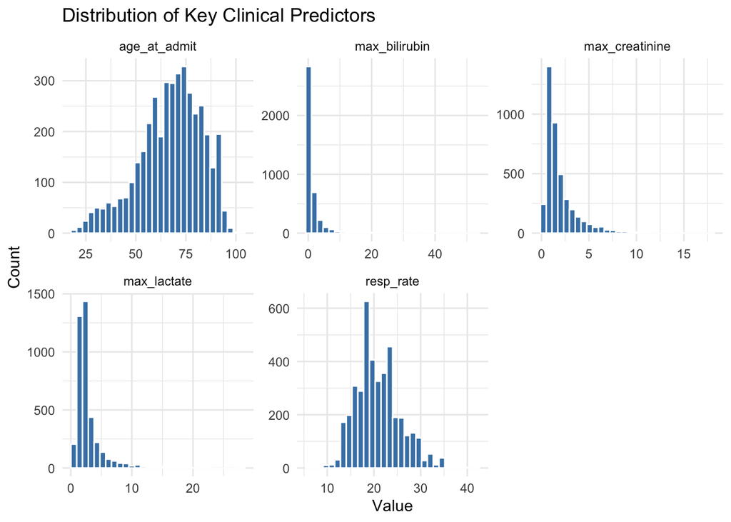

```r
library(tidyr)

# select variables of interest
key_vars <- sepsis_cohort_final %>%
  select(age_at_admit, max_lactate, max_bilirubin, max_creatinine, resp_rate) %>%
  pivot_longer(cols = everything())

# distribution plot
ggplot(key_vars, aes(x = value)) +
  geom_histogram(bins = 30, fill = "steelblue", color = "white") +
  facet_wrap(~name, scales = "free") +
  theme_minimal() +
  labs(title = "Distribution of Key Clinical Predictors", x = "Value", y = "Count")
```

```r
model_formula_final <- as.formula(
  prolonged_stay_14 ~ age_at_admit + gender + race_group + insurance +
    max_lactate + max_creatinine + max_bilirubin + max_wbc + min_platelets +
    heart_rate + mean_bp + sys_bp + resp_rate + temp_f +
    diabetes * hypertension + ckd * age_at_admit + vasopressors * max_lactate
)

# filter the data to rows w complete cases (only a few missing insurance)
train_final <- train_set %>%
  select(all_of(all.vars(model_formula_final))) %>%
  drop_na()

test_final <- test_set %>%
  select(all_of(all.vars(model_formula_final))) %>%
  drop_na()

# create the matrices
x_train <- model.matrix(model_formula_final, data = train_final)[, -1]
y_train <- as.numeric(as.character(train_final$prolonged_stay_14))

x_test  <- model.matrix(model_formula_final, data = test_final)[, -1]
y_test  <- as.numeric(as.character(test_final$prolonged_stay_14))
```

```r
# run the 3 regularized models

set.seed(123)
lasso_cv <- cv.glmnet(x_train, y_train, family = "binomial", alpha = 1)
ridge_cv <- cv.glmnet(x_train, y_train, family = "binomial", alpha = 0)
enet_cv  <- cv.glmnet(x_train, y_train, family = "binomial", alpha = 0.5)

# AUC results table
tibble(
  Model = c("Lasso", "Ridge", "Elastic Net"),
  AUC = c(
    auc(roc(y_test, as.numeric(predict(lasso_cv, x_test, s = "lambda.min", type = "response")), quiet = TRUE)),
    auc(roc(y_test, as.numeric(predict(ridge_cv, x_test, s = "lambda.min", type = "response")), quiet = TRUE)),
    auc(roc(y_test, as.numeric(predict(enet_cv, x_test, s = "lambda.min", type = "response")), quiet = TRUE))
  )
) %>%
  mutate(AUC = round(as.numeric(AUC), 4))
```

```
# A tibble: 3 × 2
  Model         AUC
  <chr>       <dbl>
1 Lasso       0.778
2 Ridge       0.775
3 Elastic Net 0.777
```

```r
coefs <- as.matrix(coef(lasso_cv, s = "lambda.min"))

# turn them into the 'lasso_importance' table your plot expects
lasso_importance <- data.frame(Predictor = rownames(coefs), Importance = abs(coefs[,1])) %>%
  filter(Predictor != "(Intercept)", Importance > 0)
```

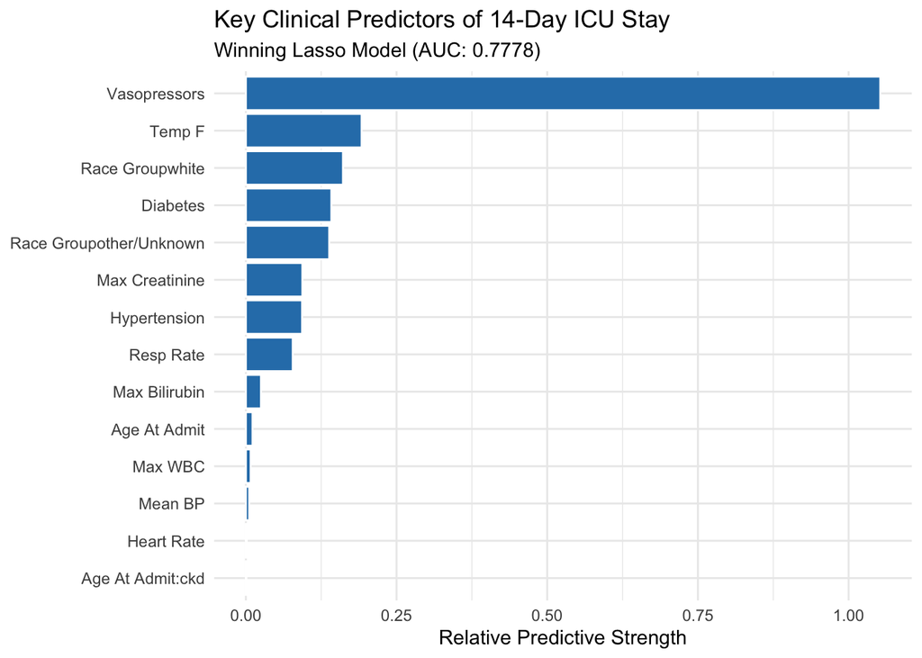

```r
library(tibble)

# clean predictor names in importance table
lasso_importance_clean <- lasso_importance %>%
  mutate(
    Predictor = Predictor %>%
      # remove the trailing '1' from binary variables
      str_replace_all("1$", "") %>%
      # replace underscores with spaces
      str_replace_all("_", " ") %>%
      str_to_title() %>%
      # fix specific lab names that shouldn't be fully capitalized
      str_replace("Wbc", "WBC") %>%
      str_replace("Bp", "BP") %>%
      str_replace("Ckd", "CKD")
  )

# plot
ggplot(lasso_importance_clean, aes(x = reorder(Predictor, Importance), y = Importance)) +
  geom_col(fill = "#2c7fb8", color = "white") +
  coord_flip() +
  theme_minimal() +
  labs(
    title = "Key Clinical Predictors of 14-Day ICU Stay",
    subtitle = "Winning Lasso Model (AUC: 0.7778)",
    x = NULL, # Removes the redundant "Predictors" label
    y = "Relative Predictive Strength"
  )
```

```r
# probabilities
lasso_probs <- predict(lasso_cv, x_test, s = "lambda.min", type = "response") %>%
  as.numeric()

# use the ROC object to find the "best threshold (Youden's J Index)
# this finds the point that balances Sensitivity and Specificity perfectly
roc_obj <- roc(y_test, lasso_probs, quiet = TRUE)
best_threshold <- coords(roc_obj, "best", ret = "threshold") %>% as.numeric()

# create new predictions based on this smarter threshold
lasso_preds_tuned <- ifelse(lasso_probs > best_threshold, 1, 0) %>%
  factor(levels = c(0, 1))

# run the confusion matrix again
conf_matrix_tuned <- confusionMatrix(lasso_preds_tuned, factor(y_test, levels = c(0, 1)), positive = "1")

# print updated results
tibble(
  Metric = c("New Threshold", "Accuracy", "Sensitivity", "Specificity"),
  Value = c(
    best_threshold,
    conf_matrix_tuned$overall["Accuracy"],
    conf_matrix_tuned$byClass["Sensitivity"],
    conf_matrix_tuned$byClass["Specificity"]
  )
) %>%
  mutate(Value = round(as.numeric(Value), 4))
```

```
# A tibble: 4 × 2
  Metric         Value
  <chr>          <dbl>
1 New Threshold 0.0945
2 Accuracy      0.744
3 Sensitivity   0.771
4 Specificity   0.741
```

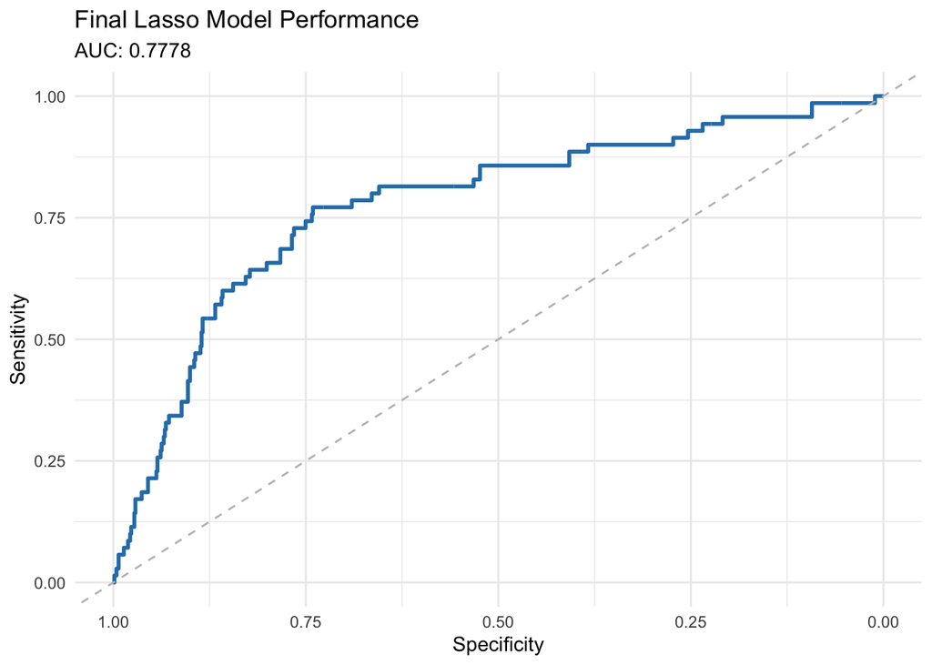

```r
# create ROC object
roc_final <- roc(y_test, lasso_probs, quiet = TRUE)

# plot using ggroc
ggroc(roc_final, colour = "#2c7fb8", size = 1) +
  geom_abline(intercept = 1, slope = 1, linetype = "dashed", color = "grey") +
  theme_minimal() +
  labs(
    title = "Final Lasso Model Performance",
    subtitle = paste("AUC:", round(auc(roc_final), 4)),
    x = "Specificity",
    y = "Sensitivity"
  ) +
  # flips the x-axis to the standard medical 1 -> 0 view
  scale_x_reverse()
```

```r
library(randomForest)

# prepare data
train_rf <- train_final %>%
  mutate(prolonged_stay_14 = as.factor(prolonged_stay_14))

test_rf <- test_final %>%
  mutate(prolonged_stay_14 = as.factor(prolonged_stay_14))

# train the forest
set.seed(123)
rf_model <- randomForest(
  model_formula_final,
  data = train_rf,
  ntree = 500,
  importance = TRUE
)

# get probabilities for the test set
# type = "prob" gives a matrix; we want the probability of "1" (long stay)
rf_probs <- predict(rf_model, test_rf, type = "prob")[, "1"]

# AUC
rf_auc <- auc(roc(as.numeric(as.character(test_rf$prolonged_stay_14)), rf_probs, quiet = TRUE))

print(paste("Random Forest AUC:", round(rf_auc, 4)))
```

```
[1] "Random Forest AUC: 0.7609"
```

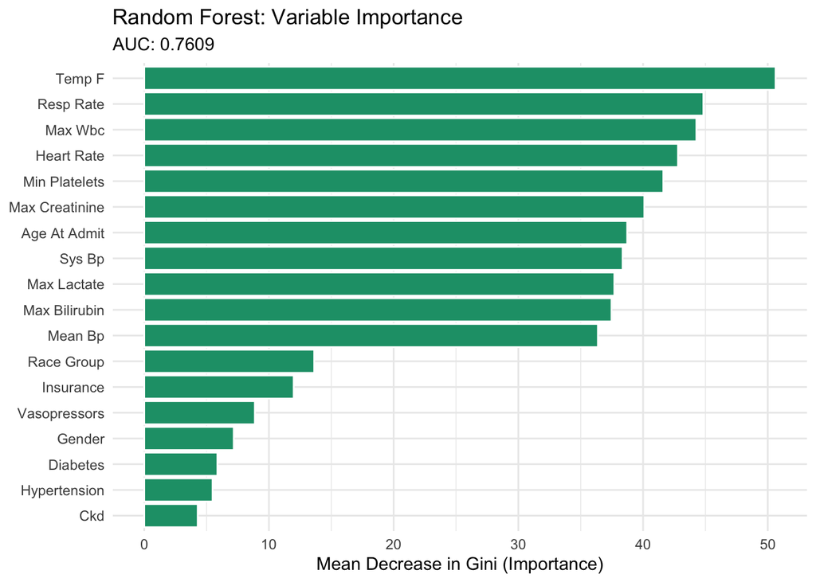

```r
# extract and clean importance data
rf_importance <- as.data.frame(importance(rf_model)) %>%
  rownames_to_column(var = "Predictor") %>%
  # 'MeanDecreaseGini' = standard measure for importance in RF!!!!!!!!
  arrange(desc(MeanDecreaseGini)) %>%
  mutate(Predictor = str_replace_all(Predictor, "_", " ") %>% str_to_title())

# plot
ggplot(rf_importance, aes(x = reorder(Predictor, MeanDecreaseGini), y = MeanDecreaseGini)) +
  geom_col(fill = "#1b9e77", color = "white") +
  coord_flip() +
  theme_minimal() +
  labs(
    title = "Random Forest: Variable Importance",
    subtitle = paste("AUC:", round(rf_auc, 4)),
    x = NULL,
    y = "Mean Decrease in Gini (Importance)"
  )
```

```r
library(xgboost)

# convert data to matrix (XGBoost only takes numeric inputs)
dtrain <- xgb.DMatrix(data = x_train, label = y_train)
dtest <- xgb.DMatrix(data = x_test, label = y_test)

# set parameters
params <- list(
  objective = "binary:logistic",
  eval_metric = "auc",
  eta = 0.1,       # Learning rate
  max_depth = 4    # Depth of trees
)

# training (with same breakups as our other 2 models)
set.seed(123)
xgb_model <- xgb.train(
  params = params,
  data = dtrain,
  nrounds = 100,   # number of boosting iterations
  evals = list(val = dtest, train = dtrain),
  print_every_n = 10,
  early_stopping_rounds = 10
)
```

```
Multiple eval metrics are present. Will use train_auc for early stopping.
Will train until train_auc hasn't improved in 10 rounds.
```

```r
# predictions and AUC
xgb_probs <- predict(xgb_model, dtest)
xgb_auc <- auc(roc(y_test, xgb_probs, quiet = TRUE))

print(paste("XGBoost AUC:", round(xgb_auc, 4)))
```

```
[1] "XGBoost AUC: 0.7429"
```

**V. RESULTS**

**Cohort / Sample Characteristics**

The final study cohort consisted of 4,077 adult sepsis patients who survived at least 48 hours following ICU admission. The population was predominantly White (62.8%), followed by Black (12.9%) and Other/Unknown (16.1%) racial groups. A significant majority of the cohort was insured through Medicare (59.2%). The age distribution was centered around a median of 69 years, reflecting a typical elderly sepsis population. Regarding clinical severity in the first 24 hours, the median maximum lactate was 2.1 mmol/L, and approximately 60.5% of patients required vasopressor support. The primary outcome, a prolonged ICU stay exceeding 14 days, occurred in 353 patients (8.6%). Various descriptive visuals were added in above cells because I aim to visualize raw data as I go, but I will add some here for project structure.

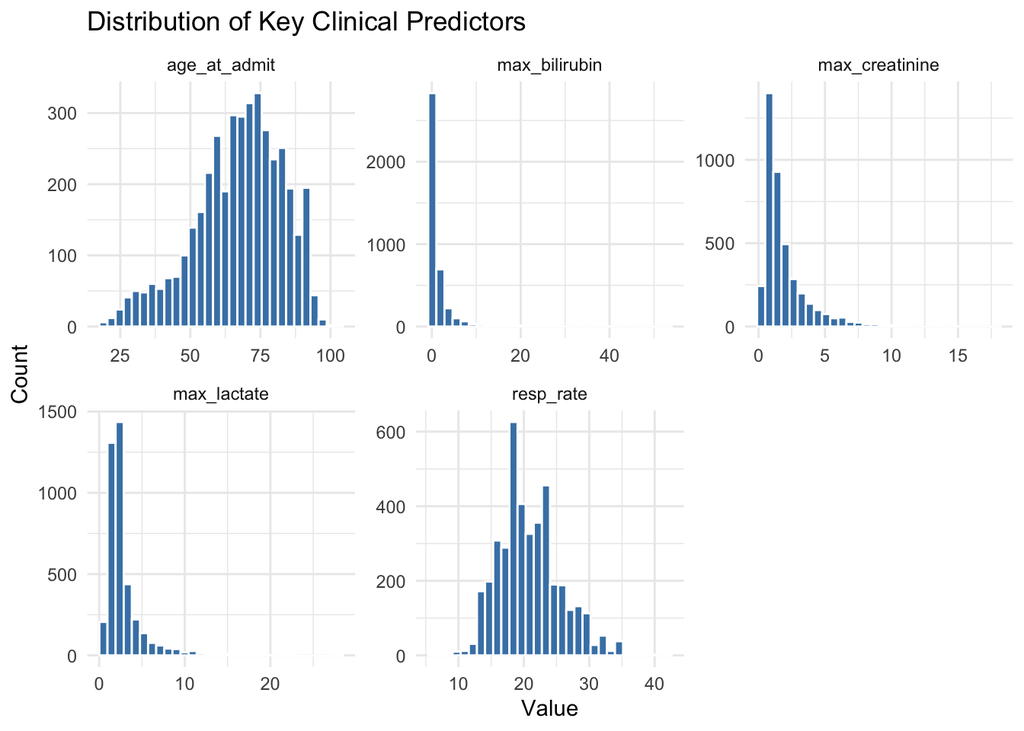

```r
# select variables of interest
key_vars <- sepsis_cohort_final %>%
  select(age_at_admit, max_lactate, max_bilirubin, max_creatinine, resp_rate) %>%
  pivot_longer(cols = everything())

# distribution plot
ggplot(key_vars, aes(x = value)) +
  geom_histogram(bins = 30, fill = "steelblue", color = "white") +
  facet_wrap(~name, scales = "free") +
  theme_minimal() +
  labs(title = "Distribution of Key Clinical Predictors", x = "Value", y = "Count")
```

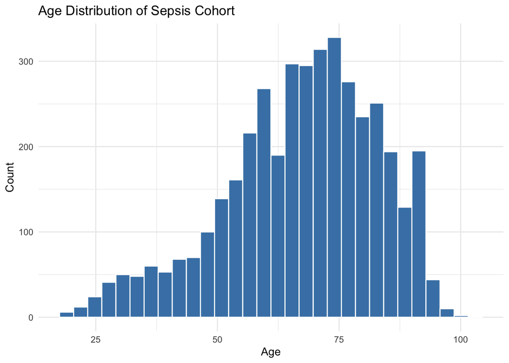

```r
# age distribution
ggplot(sepsis_cohort_final, aes(x = age_at_admit)) +
  geom_histogram(bins = 30, fill = "steelblue", color = "white") +
  theme_minimal() +
  labs(title = "Age Distribution of Sepsis Cohort", x = "Age", y = "Count")
```

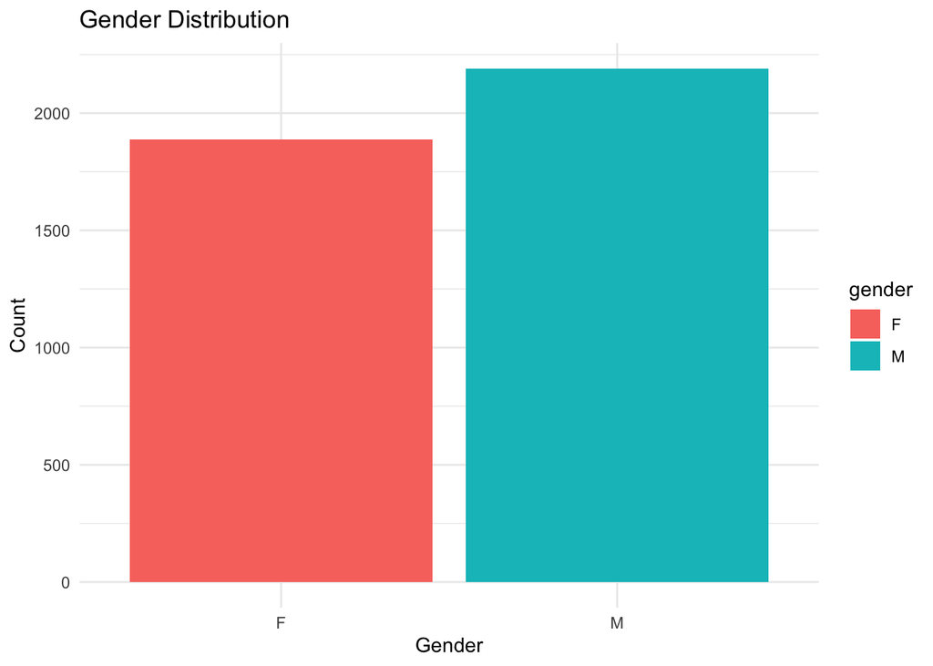

```r
# gender Breakdown
ggplot(sepsis_cohort_final, aes(x = gender, fill = gender)) +
  geom_bar() +
  theme_minimal() +
  labs(title = "Gender Distribution", x = "Gender", y = "Count")
```